# Practical B

Jolien Cremers (adapted from Gerko Vink)

Statistical Programming with R

We use the following packages:

```r
library(ggplot2)
library(dplyr)
library(magrittr)
library(MASS)
```

#### Exercises

Again, just like last time it is wise to start with fixing the random seed.

```r
set.seed(123)
```

1. **Generate two random samples of 10 numbers from a normal distribution with the below specifications. Test the null hypothesis that the population mean is 0.**
- $\mu = 0$ and $\sigma = 2$
- $\mu = 1.5$ and $\sigma = 2$

```r
x <- rnorm(10, mean = 0, sd = 2)
t.test(x)
```

```
##
##  One Sample t-test
##
## data:  x
## t = 0.24742, df = 9, p-value = 0.8101
## alternative hypothesis: true mean is not equal to 0
## 95 percent confidence interval:
##  -1.215341  1.513843
## sample estimates:
## mean of x
## 0.1492513
```

```r
x <- rnorm(10, 1.5, 2)
t.test(x)
```

```
##
##  One Sample t-test
##
## data:  x
## t = 2.9202, df = 9, p-value = 0.01703
## alternative hypothesis: true mean is not equal to 0
## 95 percent confidence interval:
##  0.432058 3.402430
## sample estimates:
## mean of x
##  1.917244
```

2. **Write a function that generates a random sample of `n` numbers from a normal distribution with a user defined mean (i.e. a mean that you can choose when running the function) and standard deviation 1, and returns the `p.value` for the test that the mean is 0.**

```r
p.value.t <- function (n, mu) {
  x <- rnorm(n, mu, 1)
  t.test(x)$p.value
}

p.value.t(n = 30, mu = 3)
```

```
## [1] 2.912617e-17
```

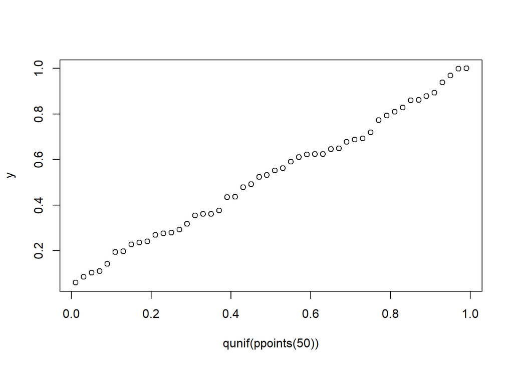

```r
y <- numeric(50)
for (i in 1:50) {
  y[i] <- p.value.t(n = 10, mu = 0)
}

qqplot(x=qunif(ppoints(50)), y)
```

The p-values follow a uniform distribution.

In a study that examined the use of acupuncture to treat migraine headaches, consenting patients on a waiting list for treatment for migraine were randomly assigned in a 2:1:1 ratio to acupuncture treatment, a “sham” acupuncture treatment in which needles were inserted at non-acupuncture points, and waiting-list patients whose only treatment was self-administered (Linde et al., 2005). The “sham” acupuncture treatment was described to trial participants as an acupuncture treatment that did not follow the principles of Chinese medicine.

4. **What is the conclusion when the outcome is classified according to numbers of patients who experienced a greater than 50% reduction in headaches over a four-week period, relative to a pre-randomization baseline?**

Use the following data

```r
data <- matrix(c(74, 71, 43, 38, 11, 65), nrow = 2, ncol = 3)
colnames(data) <- c("Acupuncture", "Sham", "Waiting list")
rownames(data) <- c("> 50% reduction", "< 50% reduction")
data
```

```
##                 Acupuncture Sham Waiting list
## > 50% reduction          74   43           11
## < 50% reduction          71   38           65
```

We start with calculating the $X^2$-test:

```r
X2test <-
  data %>%
  chisq.test()

X2test
```

```
##
##  Pearson's Chi-squared test
##
## data:  .
## X-squared = 32.486, df = 2, p-value = 8.825e-08
```

which is extremely significant. We can then calculate the expected cell frequencies

```r
X2test$expected
```

```
##                 Acupuncture     Sham Waiting list
## > 50% reduction    61.45695 34.33113     32.21192
## < 50% reduction    83.54305 46.66887     43.78808
```

and the raw residual

```r
X2test$observed - X2test$expected
```

```
##                 Acupuncture      Sham Waiting list
## > 50% reduction    12.54305  8.668874    -21.21192
## < 50% reduction   -12.54305 -8.668874     21.21192
```

as well as the Pearson residual

```r
X2test$residuals
```

```
##                 Acupuncture      Sham Waiting list
## > 50% reduction    1.599991  1.479513    -3.737418
## < 50% reduction   -1.372296 -1.268963     3.205546
```

to infer the difference in observed and expected cell frequencies. Patients on the waiting list experience `> 50% reduction` much less than we would expect under independence of treatment and outcome.

5. **Patients who received the acupuncture and sham acupuncture treatments were asked to guess their treatment at the end of their trial. What would you conclude from this data?**

```r
data <- matrix(c(82, 17, 30, 30, 26, 16), nrow = 3, ncol = 2)
colnames(data) <- c("Acupuncture", "Sham")
rownames(data) <- c("Chinese", "Other", "Don't know")
data
```

```
##            Acupuncture Sham
## Chinese             82   30
## Other               17   26
## Don't know          30   16
```

We again start with calculating the $X^2$-test:

```r
X2test <-
  data %>%
  chisq.test()

X2test
```

```
##
##  Pearson's Chi-squared test
##
## data:  .
## X-squared = 15.358, df = 2, p-value = 0.0004624
```

which is very significant. We can then calculate the expected cell frequencies

```r
X2test$expected
```

```
##            Acupuncture     Sham
## Chinese       71.88060 40.11940
## Other         27.59701 15.40299
## Don't know    29.52239 16.47761
```

and the raw residual

```r
X2test$observed - X2test$expected
```

```
##            Acupuncture        Sham
## Chinese     10.1194030 -10.1194030
## Other      -10.5970149  10.5970149
## Don't know   0.4776119  -0.4776119
```

as well as the Pearson residual

```r
X2test$residuals
```

```
##            Acupuncture       Sham
## Chinese     1.19357319 -1.5976353
## Other      -2.01721641  2.7001078
## Don't know  0.08790214 -0.1176598
```

We find that people who are receiving *true* `Acupuncture` are more inclined to believe that they receive `Chinese` acupuncture than we would expect under independence, while people wo received `Sham` acupuncture are more inclined to believe that they receive `Other` type of acupuncture. `Don't know` is more or less similarly distributed over the observed and expected frequencies.

6. **Write a function that chooses automatically whether to do the `chisq.test()` or the `fisher.test()`. Create the function such that it:**
- takes two vectors as input
- creates a table from the two vectors
- checks if there is any expected cell frequency that is smaller than 5
- and that then performs and prints the results of the appropriate test.

```r
contingencyTest <- function(x, y) {

  # Make a table out of the variables.
  tab <- table(x, y)

  #expected frequencies
  exp.freq <- (colSums(tab) %*% t(rowSums(tab))) / sum(tab)

  # Choose the correct test.
  if (any(exp.freq < 5)) {
    results <- fisher.test(x, y)
    return(results)
  } else {
    results <- chisq.test(x, y)
    return(results)
  }
}
```

A more efficient function that tests whether the expected frequencies are smaller than a threshold $t$ is:

```r
contingencyTest2 <- function(x, y, t = 5){
  test <- suppressWarnings(chisq.test(x, y))
  if (any(test$expected < t)){
    test <- fisher.test(x, y)
  }
  return(test)
}
```

The `suppressWarnings()` function is used to surpress printing of the warnings that function chi-square puts out to the console when too low expected cell-frequencies are encountered. Since we decide to use Fisher’s exact test in those situations anyway, it is redundant to print the message.

```r
bacteria %$%
  contingencyTest(ap, hilo)
```

```
##
##  Pearson's Chi-squared test with Yates' continuity correction
##
## data:  x and y
## X-squared = 2.9352, df = 1, p-value = 0.08667
```

```r
bacteria %$%
  contingencyTest2(ap, hilo)
```

```
##
##  Pearson's Chi-squared test with Yates' continuity correction
##
## data:  x and y
## X-squared = 2.9352, df = 1, p-value = 0.08667
```

8. **Does your function work differently if we only put in the first 25 rows of the `bacteria` dataset?**

```r
bacteria[1:25, ] %$%
  contingencyTest(ap, hilo)
```

```
##
##  Fisher's Exact Test for Count Data
##
## data:  x and y
## p-value = 1
## alternative hypothesis: true odds ratio is not equal to 1
## 95 percent confidence interval:
##   0.1896616 10.6212859
## sample estimates:
## odds ratio
##   1.408082
```

```r
bacteria[1:25, ] %$%
  contingencyTest2(ap, hilo)
```

```
##
##  Fisher's Exact Test for Count Data
##
## data:  x and y
## p-value = 1
## alternative hypothesis: true odds ratio is not equal to 1
## 95 percent confidence interval:
##   0.1896616 10.6212859
## sample estimates:
## odds ratio
##   1.408082
```

Yes, it performs differently: expected cell frequencies are smaller than 5 for this subset.

End of practical.